# What you can and can’t do to change your grades

Laine Wishart and Asela Gunatilake

April 11th, 2021

[Github repo](https://github.com/LaineWishart/stanford-datathon) | Team No: 113 | Track No: 1

“Nature versus nurture” debate has been a hot topic in psychology ever since the expression was coined in medieval France. Despite an individuals innate prowess and family background, one can master their own path by choosing to manage time efficiently. In this article we explore a dataset from Portugal, of secondary school performance in “math” and “Portugese”, courtesy of Paulo Cortez from the University of Minho, to understand insights the habits of the high performers. The dataset contains information from 649 students aged between 16 - 22 that attended two schools in in Portaugal in 2014, including test scores and demographic information. We have divided the attributes to two broad catagories based on environmental, non, controllable factors (e.g. age, gender, family background) and controllable factors (e.g. number of hours spent studying, frequency of going out, alcohol consumption) to understands their impact on grades. Our analyses indicate that both factors played crucial a role in determining student performance and their habits may be transferable to university students who want to improve their acadamic performance. Our analysis shows student cohorts who found a **“goldilocks”** zone between work, study and life appear to outperform other cohorts in achieving better acadamic outcomes.

```r
library(ggplot2)
library(caret)
library(tidyverse)
library(dplyr)
library(janitor)
```

```r
d.mat=read.table("data/student/student-mat.csv",sep=";",header=TRUE)
d.port=read.table("data/student/student-por.csv",sep=";",header=TRUE)
d.mat$subject = "Maths"
d.port$subject = "Portugese"
d.all <- rbind(d.mat, d.port) #%>% mutate(Medu = as.factor(Medu),
                 #studytime = as.factor(studytime))

d.all <- d.all %>% mutate(Medu = case_when(Medu == 0 ~ "None",
                                  Medu == 1 ~ "4th Grade",
                                  Medu == 2 ~ "5th - 9th Grade",
                                  Medu == 3 ~ "Secondary Education",
                                  Medu == 4 ~ "Higher Education"))

d.all <- d.all %>% mutate(freetime = case_when(
  freetime == 1 ~ "Very Low",
  freetime == 2 ~ "Low",
  freetime == 3 ~ "Average",
  freetime == 4 ~ "High",
  freetime == 5 ~ "Very High"
))

d.all <- d.all %>% mutate(goout = case_when(
  goout == 1 ~"Very Low",
  goout == 2 ~ "Low",
  goout == 3 ~ "Average",
  goout == 4 ~ "High",
  goout == 5 ~ "Very High"
))


d.all <- d.all %>% mutate(studytime = case_when(studytime == 1 ~ "[1-2)",
                                       studytime == 2 ~ "[2-5)",
                                       studytime == 3 ~ "[3-10)",
                                       studytime == 4~ "[4-10)"))



d.all$Medu = factor(d.all$Medu, levels =  c("None", "4th Grade", "5th - 9th Grade",  "Secondary Education", "Higher Education"), ordered = TRUE )
#levels(d.all$Medu) = c("None", "4th Grade", "5th - 9th Grade",  "Secondary Education", "Higher #Education")


d.all$goout = factor(d.all$goout, levels = c("Very Low","Low","Average","High",'Very High'), ordered=TRUE)

d.all$freetime = factor(d.all$freetime, levels = c("Very Low","Low","Average","High",'Very High'), ordered=TRUE)
```

# Family influence on student achievement

## The things we can’t control

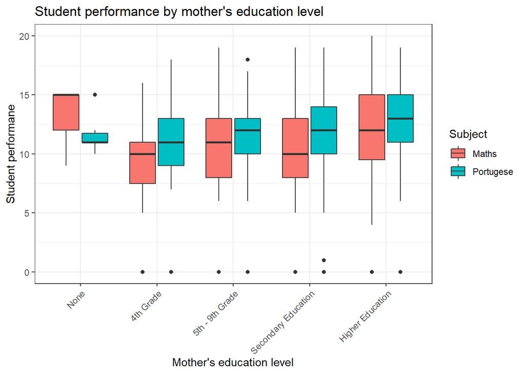

```r
d.all %>%
  ggplot(aes(x = Medu, y = G3, fill = subject)) + geom_boxplot() + labs(title = "Student performance by mother's education level", x = "Mother's education level", y = "Student performane", fill = "Subject") + theme_bw() + theme(axis.text.x = element_text(angle = 45, hjust=1))
```

## Hard work pays off

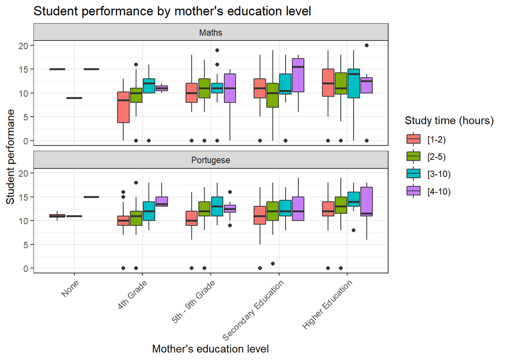

```r
d.all %>% ggplot(aes(x = Medu, y = G3, fill = studytime)) + geom_boxplot() + labs(title = "Student performance by mother's education level", x = "Mother's education level", y = "Student performane", fill = "Study time (hours)") + theme_bw() + facet_wrap(~subject, nrow = 2) + theme(axis.text.x = element_text(angle = 45, hjust=1))
```

Although parent education appears to affect how students spend their free time and shape their future academic goals, individual effort appears to pay off more for students from poorly-educated families. The above figure shows there was a larger increase in sacacemic achievement per increase in hours studies for students with poorly-educated mothers compared to students with highly educated mothers.

# Student choices on student achievement

## The amount of hours you study translates to higher marks, but at a diminishing rate

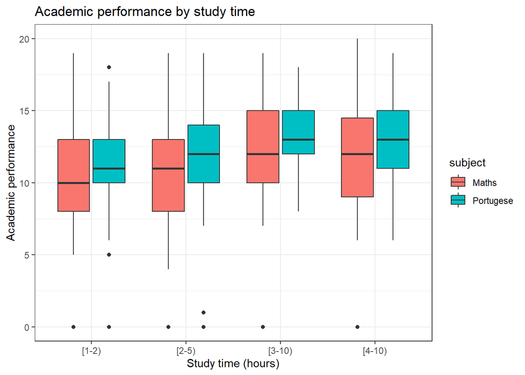

```r
d.mat$G4 <- (0.3*d.mat$G1 + 0.3*d.mat$G2 + 0.4*d.mat$G3)/20
d.port$G4 <- (0.3*d.port$G1 + 0.3*d.port$G2 + 0.4*d.port$G3)/20



d.all %>% ggplot(aes(x = studytime, y = G3, fill = subject)) + geom_boxplot() + labs( title = "Academic performance by study time", x = "Study time (hours)", y = "Academic performance") + theme_bw()
```

In most cases, students who studied more hours per week were able to transfer their effort in to better grades albeit at a diminishing rate. However, it appears the scores deteriorated for the cohort of students that studied more than 10 hours per week relative to the cohort of students who reportedly studied between 5 to 10 hours per week. This may be indicative of additional studying time infringing on students’ free-time and the ability to engage in social activities. As we explore in the subsequent chapters, *“all-work no play”* strategy may not neccasarly equates to gains in grades.